# Course Guide

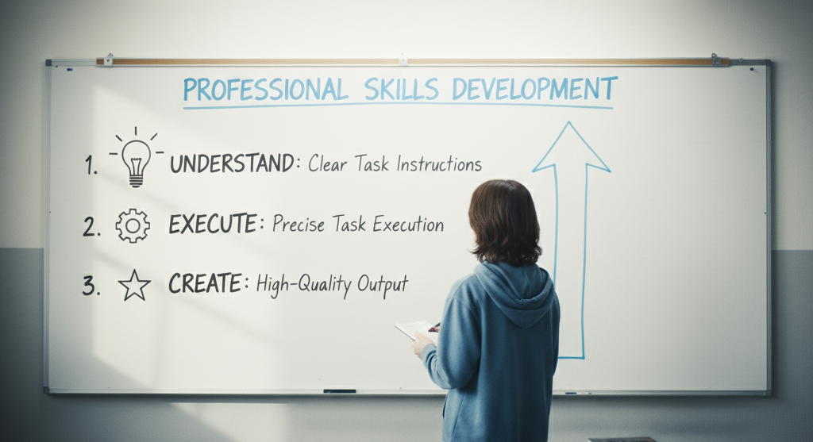

## 1 Purpose

This guide outlines the course policies and expectations for students enrolled at THU. It is essential that all students read and understand these guidelines to ensure a successful learning experience.

Additionally, this guide can help students prepare as professionals in the workplace by:

- **Understanding** task instructions clearly
- **Executing** the task precisely
- **Creating** a high-quality output

## 2 Prerequisites

Before the course begins, ensure you have the following accounts, software, and technical support resources set up.

### 2.1 Accounts

- THU official **email** account (xyz@thu.edu.tw) https://tmail.thu.edu.tw/
- THU official **MS Teams** account (xyz@**tdrive**.thu.edu.tw) for accessing any MS Apps https://login.microsoftonline.com
- Be aware of the **difference between THU official email and MS Teams** account. Official email account won’t be able to access MS Teams. Only **official MS Teams** account can access MS Teams.

### 2.2 Software & Apps

- iLearn App (Tronclass) on smartphone https://ilearn.thu.edu.tw
- MS Word, MS PowerPoint, MS Teams, MS OneNote
- Google Chrome
- THU AI Apps
  - 咚咚妞網頁版 https://dondonweb.ithu.tw/
- For Python Programming Labs:
  - Python https://www.python.org/downloads/
  - Microsot VS Code https://code.visualstudio.com/download
  - GitHub account https://www.github.com
- For R Programming Labs:
  - R https://cran.r-project.org/mirrors.html
  - RStudio https://posit.co/download/rstudio-desktop/
  - GitHub account https://www.github.com

## 3 Communication

Mastering professional email communication help you make a positive impression on everyone you work with. Each email you write is an opportunity to show **respect**, **clarity**, and **professionalism**, qualities that will set you apart in any field you choose.

- THU’s official email will be used for all course-related communication. (e.g., xyz@thu.edu.tw)
- To send course-related emails to the instructor, log in to https://tmail.thu.edu.tw and send your email from there. This ensures emails are not filtered as spam by the university system.
- Emails sent during work hours (9AM-5PM) will be responded to within a reasonable time.
- Course-related email should include course name, your name, student ID, department, and a clear subject line. Then, provide detailed information about your inquiry in the email body.
  - Example:

    > Subject: Question About Assignment 2 Deadline - Introduction to Data Science

    > Dear Professor [Name],

    > Course: Introduction to Data Science (CS 301)  
    > Student Name: Sarah Johnson  
    > Student ID: 2023456789  
    > Department: Computer Science

    > I am writing to inquire about the deadline for Assignment 2, which is currently scheduled for November 15th.

    > Due to a medical appointment that I have scheduled on that day, I wanted to ask if it would be possible to submit the assignment one day early on November 14th, or if there is any flexibility with the submission time on the 15th.

    > I have already completed most of the assignment and want to ensure that I submit it properly without any issues. Please let me know if you need any documentation regarding my appointment.

    > Thank you for your time and consideration. I look forward to your response.

    > Best regards,  
    > Sarah Johnson
- Additional communication methods may be explored based on specific requirements.

## 4 Attendance

Attending class regularly develops the **professional work ethic** that employers value most in the workplace. This habit shows you are **responsible and reliable**, qualities essential for career success.

- Attendance at all classes is mandatory for students.
- Students must check in using the iLearn App for each class during the ‘check-in period.’
- Make sure you are connected to THU Wi-Fi and that GPS is turned on in your smartphone.
- If any error occurs during check-in on your smartphone, log out of the iLearn APP and log back in, then attempt check-in again. If the error persists, then contact THU technical support.
- For technical inquiries, contact 04-23590121# 30211, ilearn@thu.edu.tw

## 5 Workload

To succeed in this course, it is important to understand the expected workload. Based on past experiences, students typically spend one to two hours per week, outside of class time, reviewing course materials and preparing for the next class.

## 6 Course Components

### 6.1 Assignments

Every assignment you complete is a step toward becoming the professional you want to be. Embrace each task as a **chance** to grow your skills and prove to yourself that you can **achieve excellence through dedication and effort**.

- The assignment must be your own.
- Use the template provided by the instructor.
- Copying the contents directly from AI tools is not allowed for writing assignments.
- Homework is due by **5 PM on the Friday** of the same week it’s announced.
- Convert a written assignment to PDF format. You can use MS Word or PowerPoint to save the file as a **PDF**.
- All assignment files must follow standard naming convention: `StudentID_Name_Keyword.pdf`
  - Example: `S123456_Jane_Workflow.pdf`
- For a video assignment,
  1. Upload the video to your **Google Drive**.
  2. Submit a link to the video to iLearn.
- To avoid submission errors, submit your work at least one hour before the deadline.
- For grammar and spelling checks, use tools like Grammarly or Microsoft Editor.
- Submit assignments by the deadline. Contact the instructor before the due date if you need to discuss alternative arrangements.

### 6.2 Labs

In-class labs are where learning comes alive, where you transform knowledge into real skills you can use in your career. Embrace each lab session as a chance to experiment, learn from mistakes, and build the confidence to tackle any challenge you’ll face as a professional.

- To follow the lecture properly, change the computer’s default language to English.
- Ensure you can use MS Teams, MS OneNote before the lab session.
- Listen carefully to the instructor’s explanation before starting the lab.
- Complete the lab within the allotted time.
- Save your work frequently to avoid data loss.
- Double-check your work before submission.
- Submit the lab assignment to iLearn before deadline.

### 6.3 Exams

Every exam is a chance to prove to yourself how much you’ve learned and how capable you are. Your efforts in preparing for exams reflect your commitment to excellence and your readiness to take on future challenges with confidence.

- If you arrive late, you will not be permitted to take the exam.
- Each exam is 50 minutes long.
- Mid-term exam: 20 multiple-choice questions.
- Final exam: 20 multiple-choice questions or may be substituted by a final presentation.
- To take an exam, use the iLearn on a computer.
- If the exam is held in a computer lab, use the computer provided. Personal laptops are not allowed.
- During the exam, all personal belongings (bags, phones, smartwatches, etc.) must be placed at the front of the classroom.
- No talking or any form of communication is allowed during the exam.
- Once you finished the exam, submit it on iLearn and leave the classroom quietly.
- The type of exam is subject to change depending on the progress of the course.

### 6.4 Presentations

To help students effectively enhance their presentation skills, this course incorporates **professional-level presentation practice** modeled after TED Talks.

- The use of devices such as PCs, phones, and tablets is prohibited during the presentation.
- Presentations should last between 3 to 5 minutes depending on the class size.
- The ‘final’ slide file (e.g., PowerPoint) should be turned in no later than 5 PM on the Friday preceding the presentation week. The slides are intended to help you organize your thoughts, but they are not permitted for use during the presentation.
- Presentation topics will be assigned by the instructor.
- Notes or scripts are not allowed during the presentation.
- The evaluation criteria include:
  - Content (40%)
  - Delivery (30%)
  - Body Language (20%)
  - Time Management (10%)
- The oral presentation format largely follows TED’s style: no scripts, no slides.
  - Leadership & Management
    - Why good leaders make you feel safe, Simon Sinek, https://www.ted.com/talks/simon_sinek_why_good_leaders_make_you_feel_safe
    - The Making of an Investment Banker, Jim Donovan, https://youtu.be/3Pk8EmyK7kw?si=GnH8H7LLA2U8RDeT
    - LEADERSHIP LAB: The Craft of Writing Effectively, Larry McEnerney, https://youtu.be/vtIzMaLkCaM?si=bt18GUas3eRDBS8C
    - Arnold Schwarzenegger Leaves the Audience SPEECHLESS | One of the Best Motivational Speeches Ever, Arnold Schwarzenegger, https://youtu.be/1bumPyvzCyo?si=XZWiS-DfzPoKUMOB
  - Communication & Public Speaking
    - Good Presentation VS Bad Presentation, Project IDEA, https://youtu.be/V8eLdbKXGzk?si=xJF0uulzrKYgENV9
    - How to Start a Speech, Conor Neill, https://youtu.be/w82a1FT5o88?si=2m_FnojM7tV1laoT
    - Communication Tips for Non-Native English Speakers, Matt Abrahams, https://youtu.be/5LOSNDJgkFs?si=xVrMPLvOmhsfoAfY
    - Become great with your technical skills AND communication skills, Vinh Giang, https://youtu.be/pNQjUGy1oEc?si=A8f54E-PGbmg46ek
    - Powerful technique to quickly improve how you speak, Vinh Giang, https://youtu.be/mXPIJosPsVU?si=I793XwxZaUHBb8o1
    - Tory MP fails to understand Glaswegian accent of SNP’s David Linden, The Guardian, https://youtu.be/I4k8dR04TzA?si=BL-E4Wyxb1vEUaLK
  - Learning & Productivity
    - Study Less Study Smart, Marty Lobdell, https://youtu.be/IlU-zDU6aQ0?si=xN0ftskIMX3BRWg6
    - How to Make Learning as Addictive as Social Media | Duolingo’s Luis Von Ahn | TED, Luis von Ahn, https://youtu.be/P6FORpg0KVo?si=vRHFaR-kSo4cgOBQ
  - Professional Development & Etiquette
    - 8 Email Etiquette Tips - How to Write Better Emails at Work, Harvard Business Review, https://youtu.be/1XctnF7C74s?si=HE5uR7tEfxBetNRd

## 7 Policies

### 7.1 Academic Integrity and Misconduct

- Any academic misconduct will be reported to your department and the university.
- For details about academic misconduct, refer to THU Academic Regulations. For example, Article 33. Being absent from the exam without an approved leave, the results of such a missed exam shall be counted as zero. Cheating on midterm, final, or graduation exams will result in the semester results being counted as zero.

### 7.2 AI Usage

AI technologies can be powerful tools to **enhance your learning** and **productivity**. However, it is crucial to use them **ethically** and **responsibly** to maintain academic integrity.

- AI tools may be used for brainstorming and research, but **all written work must be in your own words**.
- If any AI systems are used in your work, specify the name of the AI system, its purpose, and its output as detailed as possible to avoid plagiarism.
  - **Example: Using AI for brainstorming**

    > **AI System Used:** ChatGPT-4  
    > **Purpose:** Generate initial ideas for marketing strategies  
    > **Output:** The AI suggested five marketing approaches: social media campaigns, email marketing, influencer partnerships, content marketing, and SEO optimization. I selected content marketing and developed my own strategy based on course concepts.

## 8 Support Resources

### 8.1 Technical Support

- THU Technical Support:
  - https://lis.thu.edu.tw/web/page/page.php?lang=en&scid=54&sid=96
- THU Helpdesk:
  - https://helpdesk.thu.edu.tw/

### 8.2 Office Hours

- Office hours will be announced in class.
- Appointments can be made with prior arrangement.